# Predicting Titanic Passenger Survival

Author

Tahir Hussain, Jaylon Huang, Rakshit Kapoor, and Teeba Obaid

# 1 Summary

This report investigates how accurately passenger survival on the RMS *Titanic* can be predicted from pre-departure demographic and ticket records, and whether domain-informed optional predictors and interactions improve upon a core set of correlation-selected features. Using the publicly available Kaggle Titanic dataset (891 labelled passengers partitioned via a 70/30 stratified split into 623 development observations and 268 held-out test observations, plus 418 unlabelled test records), we perform exploratory data analysis, fold-isolated missing-value imputation and correlation-based feature selection, and evaluate regularized logistic regression pipelines. On the development set, five-fold stratified cross-validation accuracy rises from 61.6% for a majority-class baseline to 77.8% for a five-feature logistic regression model and 82.2% (area under the receiver operating characteristic curve of 0.870) when adding age, family size, passenger title indicators, and the interaction between sex and passenger class. On the independent held-out test set, the extended logistic regression model achieves 84.3% accuracy and an F1 score of 0.784, confirming that passenger sex, youth and marital titles, ticket class, and family structure are the strongest predictors of survival. These results reflect statistical associations within a single historical disaster where age and cabin records were not missing completely at random, and they should not be interpreted as causal effects.

# 2 Introduction

The sinking of the RMS *Titanic* on April 15, 1912 remains one of the best-documented maritime disasters in modern history. Historical and sociological studies have shown that survival was strongly shaped by evacuation norms (“women and children first”) and differences in social class (Hall 1986; Elinder and Erixson 2012).

In this project, we ask a predictive research question: **how accurately can a passenger’s survival on the Titanic be predicted from demographic and ticket information available prior to departure, and does adding domain-informed optional features and interactions improve upon our core correlation-selected predictors?** Using the Kaggle Titanic dataset (Cukierski 2012), we first conduct an exploratory data analysis on the development set and save the cleaned datasets to the processed data folder. We then build and evaluate a regularized logistic regression classification model using five-fold stratified cross-validation and an independent held-out test set.

# 3 Exploratory data analysis

This section explores the Titanic passenger data before any model is built. We check the structure of the data and how much of it is missing, compare every passenger characteristic with the outcome we want to predict (whether the passenger survived, coded 1, or died, coded 0), and clean and transform the data so that it is ready for modelling. We finish by ranking the features by how strongly they relate to survival and choosing the five that we will carry into the initial model.

We use Python with pandas (McKinney 2010), scikit-learn (Pedregosa et al. 2011), matplotlib (Hunter 2007) and seaborn (Waskom 2021). The passenger records come from the Kaggle “Titanic: Machine Learning from Disaster” competition (Cukierski 2012). Each row is one passenger. Kaggle supplies two files: a training file of 891 passengers whose survival outcome is known, and a test file of 418 passengers whose outcome is hidden.

```python
from pathlib import Path
import numpy as np
import pandas as pd
import matplotlib.pyplot as plt
from matplotlib.patches import Patch
import seaborn as sns
from IPython.display import display
from sklearn.feature_selection import mutual_info_classif
from sklearn.model_selection import train_test_split
import shutil
import subprocess
from zipfile import ZipFile

SEED = 522  # fixed seed so that every teammate gets the same mutual-information values
sns.set_theme(style="whitegrid", context="notebook")
plt.rcParams.update({"figure.dpi": 110, "axes.titlesize": 12, "axes.labelsize": 11})
SURV, DIED = "#0072B2", "#D55E00"
PALETTE = {"Survived": SURV, "Did not survive": DIED}

# The report is rendered from analysis/, so the data folder is one level up.
def find_root(start=Path.cwd()):
    for p in [start, *start.parents]:
        if (p / "pyproject.toml").exists():
            return p
    return start
ROOT = find_root()
RAW_DIR, PROC_DIR = ROOT / "data" / "raw", ROOT / "data" / "processed"

RAW_DIR.mkdir(parents=True, exist_ok=True)
PROC_DIR.mkdir(parents=True, exist_ok=True)

# Download the Kaggle data if the raw CSV files are not already present.
train_path = RAW_DIR / "train.csv"
test_path = RAW_DIR / "test.csv"

if not (train_path.exists() and test_path.exists()):
    kaggle_executable = shutil.which("kaggle")

    if kaggle_executable is None:
        raise RuntimeError(
            "Kaggle CLI was not found. Run `uv sync` to install project dependencies."
        )

    print("Downloading Titanic data from Kaggle...")

    subprocess.run(
        [
            kaggle_executable,
            "competitions",
            "download",
            "-c",
            "titanic",
            "-p",
            str(RAW_DIR),
        ],
        check=True,
    )

    zip_path = RAW_DIR / "titanic.zip"

    # Extract the downloaded CSV files into data/raw/.
    with ZipFile(zip_path, "r") as zip_file:
        zip_file.extractall(RAW_DIR)

    # Check that both required files were extracted.
    missing_files = [
        filename
        for filename in ["train.csv", "test.csv"]
        if not (RAW_DIR / filename).exists()
    ]

    if missing_files:
        raise FileNotFoundError(
            f"Expected files were not found after extraction: {missing_files}"
        )

    # Remove the ZIP file after extraction.
    zip_path.unlink()

    print("Titanic data downloaded and extracted successfully.")

else:
    print("Raw Titanic data already exists. Skipping download.")

# Read the raw data.
train = pd.read_csv(train_path)
test = pd.read_csv(test_path)

train, holdout = train_test_split(
    train,
    test_size=0.30,
    stratify=train["Survived"],
    random_state=SEED
)

print(f"Training data: {train.shape[0]} rows x {train.shape[1]} columns")
print(f"Test data: {test.shape[0]} rows x {test.shape[1]} columns")
```

```
Raw Titanic data already exists. Skipping download.
Training data: 623 rows x 12 columns
Test data: 418 rows x 11 columns
```

## 3.1 Training and test data

The Kaggle Titanic dataset consists of two files: a training file containing 891 passengers with known survival outcomes, and a test file containing 418 passengers whose survival outcomes are withheld. To enable independent model evaluation, we partition the 891 labelled observations into a training set (70%) and a held-out test set (30%) using stratified random sampling to preserve approximately the original proportions of survivors and non-survivors.

We use the new training set for exploratory data analysis, preprocessing decisions, and model development. The held-out test set is reserved for final performance evaluation, while Kaggle’s original unlabelled test file remains separate for generating predictions.

## 3.2 The variables

Table 1 describes each column in the data. The last column of the table says what we expect to do with it, which we justify in the sections below.

| Column in the data | Meaning | Plan |
| --- | --- | --- |
| Survived | Outcome: 1 if the passenger survived, 0 if not (the target) | Target |
| Pclass | Ticket class: 1 (first), 2 (second) or 3 (third) | Candidate |
| Sex | Male or female | Candidate |
| Age | Age in years (fractional for infants) | Candidate, needs imputation |
| SibSp | Number of siblings or spouses travelling with the passenger | Used to build family size |
| Parch | Number of parents or children travelling with the passenger | Used to build family size |
| Fare | Ticket price in pounds | Candidate, log transform |
| Cabin | Cabin number, mostly missing | Reduced to a cabin-recorded flag |
| Embarked | Port of boarding: Cherbourg, Queenstown or Southampton | Candidate, needs imputation |
| Name | Passenger name including title (for example Mr or Mrs) | Only the title is used |
| Ticket | Ticket number | Excluded |
| PassengerId | Row identifier | Excluded (identifier only) |

*Table 1. Description of each column in the Titanic data and how we plan to use it.*

## 3.3 A first look at the training data

```python
display(train.head())
display(train.describe().T.round(2))
```

|  | PassengerId | Survived | Pclass | Name | Sex | Age | SibSp | Parch | Ticket | Fare | Cabin | Embarked |
| --- | --- | --- | --- | --- | --- | --- | --- | --- | --- | --- | --- | --- |
| 263 | 264 | 0 | 1 | Harrison, Mr. William | male | 40.0 | 0 | 0 | 112059 | 0.0000 | B94 | S |
| 42 | 43 | 0 | 3 | Kraeff, Mr. Theodor | male | NaN | 0 | 0 | 349253 | 7.8958 | NaN | C |
| 43 | 44 | 1 | 2 | Laroche, Miss. Simonne Marie Anne Andree | female | 3.0 | 1 | 2 | SC/Paris 2123 | 41.5792 | NaN | C |
| 844 | 845 | 0 | 3 | Culumovic, Mr. Jeso | male | 17.0 | 0 | 0 | 315090 | 8.6625 | NaN | S |
| 175 | 176 | 0 | 3 | Klasen, Mr. Klas Albin | male | 18.0 | 1 | 1 | 350404 | 7.8542 | NaN | S |

|  | count | mean | std | min | 25% | 50% | 75% | max |
| --- | --- | --- | --- | --- | --- | --- | --- | --- |
| PassengerId | 623.0 | 442.94 | 254.13 | 1.00 | 228.5 | 441.00 | 655.50 | 891.00 |
| Survived | 623.0 | 0.38 | 0.49 | 0.00 | 0.0 | 0.00 | 1.00 | 1.00 |
| Pclass | 623.0 | 2.31 | 0.84 | 1.00 | 2.0 | 3.00 | 3.00 | 3.00 |
| Age | 500.0 | 29.27 | 14.19 | 0.67 | 20.0 | 28.00 | 37.25 | 74.00 |
| SibSp | 623.0 | 0.48 | 1.06 | 0.00 | 0.0 | 0.00 | 1.00 | 8.00 |
| Parch | 623.0 | 0.39 | 0.81 | 0.00 | 0.0 | 0.00 | 0.00 | 6.00 |
| Fare | 623.0 | 32.64 | 53.46 | 0.00 | 7.9 | 13.42 | 31.00 | 512.33 |

*Table 2. The first five training rows (top) and summary statistics for the numeric columns (bottom).*

The training data has 623 passengers and 12 columns. Passenger class, sex, siblings and spouses, parents and children, and fare are recorded for everyone. Age, cabin and port of boarding have gaps, which we examine next.

Before comparing features, we check how balanced the target is. A model that predicts “did not survive” for everyone would already be right about 62% of the time on this data, so any model we build has to beat that baseline.

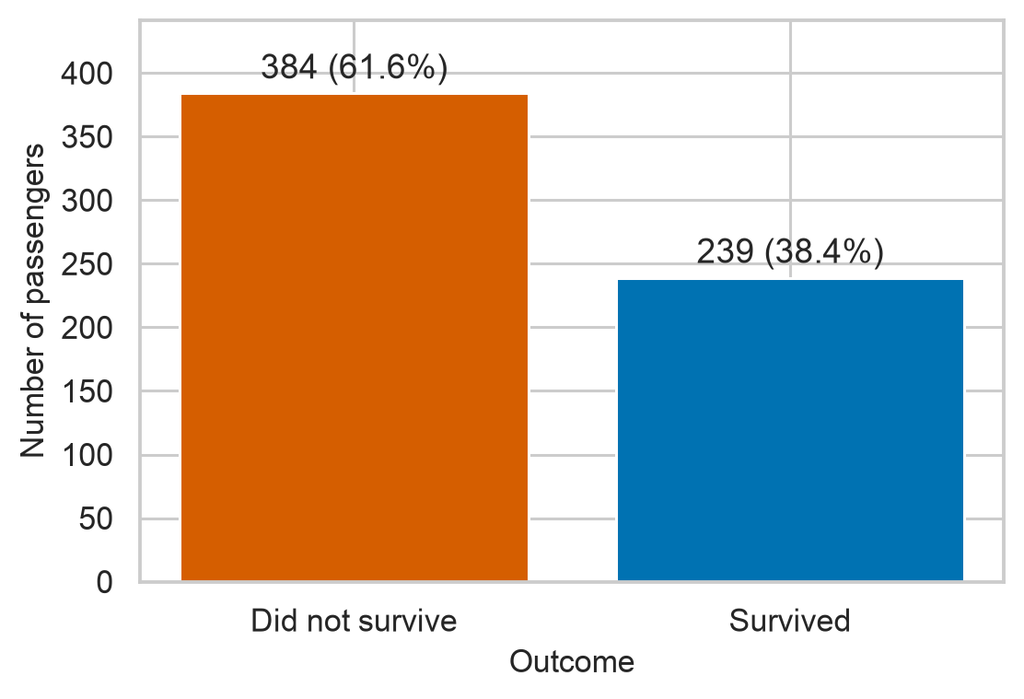

```python
eda = train.copy()
eda["Outcome"] = eda["Survived"].map({0: "Did not survive", 1: "Survived"})

counts = eda["Outcome"].value_counts().reindex(["Did not survive", "Survived"])
fig, ax = plt.subplots(figsize=(5.5, 3.6))
bars = ax.bar(counts.index, counts.values, color=[DIED, SURV])
for b, n in zip(bars, counts.values):
    ax.text(b.get_x() + b.get_width() / 2, n + 6, f"{n} ({n / counts.sum():.1%})",
            ha="center", va="bottom")
ax.set_ylabel("Number of passengers")
ax.set_xlabel("Outcome")
ax.set_ylim(0, counts.max() * 1.15)
plt.show()
```

*Figure 1. Number of training passengers who survived and who did not. The classes are moderately imbalanced, with about 38% survivors.*

## 3.4 Missing data

We now measure how much of each column is missing in the training set. For comparison we also count the missing values in the test file, because it will be cleaned in the same way later. These counts do not influence any decision.

```python
cols = list(test.columns)
missing = pd.DataFrame({
    "Training: missing (n)": train[cols].isna().sum(),
    "Training: missing (%)": (train[cols].isna().mean() * 100).round(1),
    "Test: missing (n)": test[cols].isna().sum(),
    "Test: missing (%)": (test[cols].isna().mean() * 100).round(1),
})
missing = missing[(missing.iloc[:, [0, 2]] > 0).any(axis=1)].sort_values(
    "Training: missing (%)", ascending=False
)
missing
```

|  | Training: missing (n) | Training: missing (%) | Test: missing (n) | Test: missing (%) |
| --- | --- | --- | --- | --- |
| Cabin | 482 | 77.4 | 327 | 78.2 |
| Age | 123 | 19.7 | 86 | 20.6 |
| Embarked | 1 | 0.2 | 0 | 0.0 |
| Fare | 0 | 0.0 | 1 | 0.2 |

*Table 3. Columns with missing values in the training data and in the test data.*

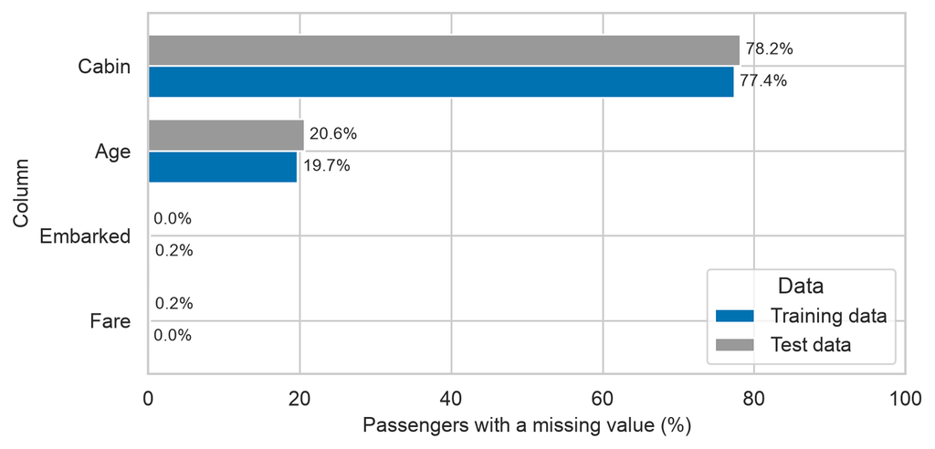

```python
plot_df = missing[["Training: missing (%)", "Test: missing (%)"]]
plot_df.columns = ["Training data", "Test data"]
ax = plot_df.iloc[::-1].plot.barh(figsize=(7.5, 3.6), color=[SURV, "#999999"], width=0.75)
ax.set_xlabel("Passengers with a missing value (%)")
ax.set_ylabel("Column")
ax.set_xlim(0, 100)
for c in ax.containers:
    ax.bar_label(c, fmt="%.1f%%", padding=3, fontsize=9)
ax.legend(title="Data")
plt.show()
```

*Figure 2. Percentage of missing values per column. The two files have very similar gaps, so one cleaning recipe can serve both.*

Cabin is missing for 77.4% of training passengers (482 of 623), age for 19.7% (123), and port of boarding for only 0.2% (1). The test file shows the same pattern for cabin (78.2%) and age (20.6%), and has one missing fare. No other column has gaps.

Missing values are not always random, so we check whether being missing is itself related to survival.

```python
overall = train["Survived"].mean()

def rate_bar(ax, data, col, order=None, xlabel="", labels=None):
    """Bar chart of the survival rate for each level of `col`, with group sizes."""
    g = data.groupby(col, observed=True)["Survived"].agg(["mean", "size"])
    if order is not None:
        g = g.reindex(order)
    names = labels if labels is not None else [str(i) for i in g.index]
    bars = ax.bar(names, g["mean"] * 100, color=SURV)
    for b, m, n in zip(bars, g["mean"], g["size"]):
        ax.text(b.get_x() + b.get_width() / 2, m * 100 + 1.5, f"{m:.0%}\n(n={n})",
                ha="center", va="bottom", fontsize=9)
    ax.axhline(overall * 100, ls="--", color="grey", lw=1, label="Overall survival rate (38%)")
    ax.set_ylim(0, 115)
    ax.set_yticks(range(0, 101, 20))
    ax.legend(loc="upper right", fontsize=8, frameon=False)
    ax.set_xlabel(xlabel)
    ax.set_ylabel("Survival rate (%)")

flags = train.assign(AgeKnown=train["Age"].notna(), CabinKnown=train["Cabin"].notna())
```

**Age recorded?**

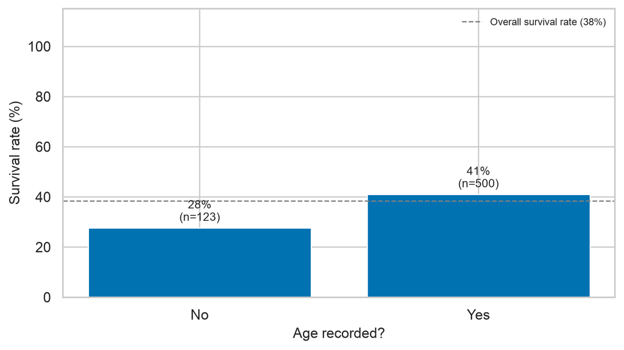

```python
fig, ax = plt.subplots(figsize=(7, 4))
rate_bar(ax, flags, "AgeKnown", order=[False, True], xlabel="Age recorded?", labels=["No", "Yes"])
fig.tight_layout()
plt.show()
```

**Cabin recorded?**

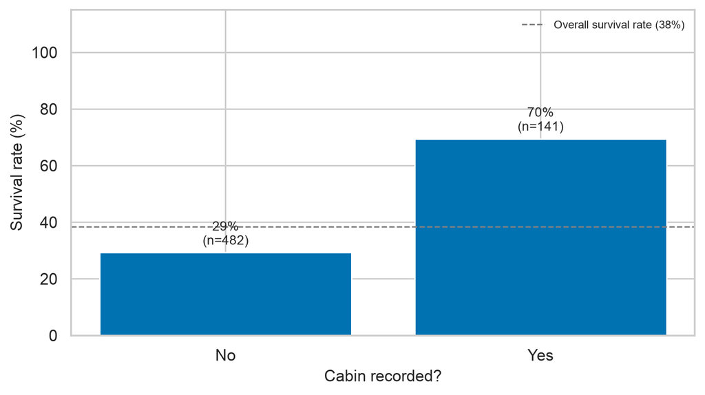

```python
fig, ax = plt.subplots(figsize=(7, 4))
rate_bar(ax, flags, "CabinKnown", order=[False, True], xlabel="Cabin recorded?", labels=["No", "Yes"])
fig.tight_layout()
plt.show()
```

*Figure 3. Survival rate by whether age and cabin were recorded. Use the tabs to switch between the two. The dashed line is the overall survival rate, and numbers in brackets are group sizes.*

Passengers with no recorded age survived approximately 28% of the time compared with 41% for those with a recorded age, and passengers with no recorded cabin survived approximately 29% compared with 70% for those with a cabin. These differences suggest that missingness may be associated with survival, so it is worth keeping simple “was it recorded?” flags next to the imputed values. Cabin in particular tells us more through whether it exists than through its content, so we do not try to fill it in.

**Decisions for missing data.** We fill in age using the median age of passengers with the same title, because titles such as “Master” (boys) and “Mrs” separate age groups far better than one overall median. We fill the missing ports with the most common port, and the single missing fare in the test file with the median fare of the same ticket class. For cabin we keep only a yes/no flag. All fill-in values are learned from the training data only and then applied unchanged to the test data, so no information leaks from the test file. For predictive modelling, missing values are imputed separately within each cross-validation training fold using the same strategies, preventing validation-fold information from influencing the imputation values.

## 3.5 Comparing each feature with survival

We now look at each feature on its own against survival. Throughout, the dashed line in the bar charts marks the overall survival rate of 38%.

```python
def extract_title(names):
    """Pull the title (Mr, Mrs, ...) out of a passenger name and group the rare ones."""
    t = names.str.extract(r" ([A-Za-z]+)\.", expand=False)
    t = t.replace({"Mlle": "Miss", "Ms": "Miss", "Mme": "Mrs"})
    return t.where(t.isin(["Mr", "Mrs", "Miss", "Master"]), "Rare")

def add_simple_features(df):
    """Features that need no learned values, so they are safe to build on any dataset."""
    out = df.copy()
    out["Title"] = extract_title(out["Name"])
    out["FamilySize"] = out["SibSp"] + out["Parch"] + 1
    out["IsAlone"] = (out["FamilySize"] == 1).astype(int)
    out["HasCabin"] = out["Cabin"].notna().astype(int)
    out["AgeMissing"] = out["Age"].isna().astype(int)
    return out

eda = add_simple_features(eda)
```

### 3.5.1 Sex and passenger class

**Sex**

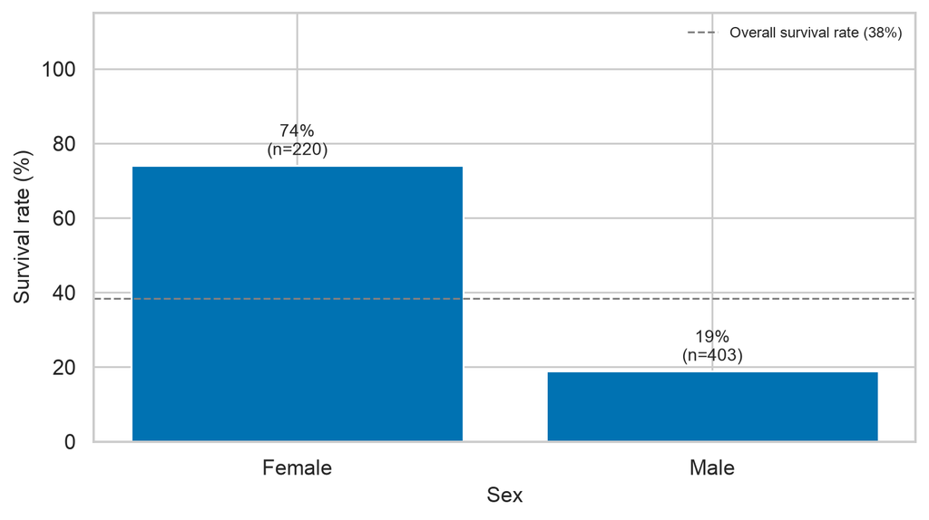

```python
fig, ax = plt.subplots(figsize=(7, 4))
rate_bar(ax, eda, "Sex", order=["female", "male"], xlabel="Sex", labels=["Female", "Male"])
fig.tight_layout()
plt.show()
```

**Passenger class**

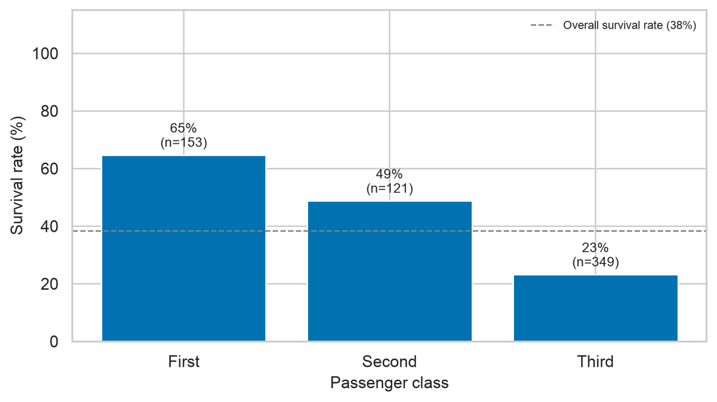

```python
fig, ax = plt.subplots(figsize=(7, 4))
rate_bar(ax, eda, "Pclass", order=[1, 2, 3], xlabel="Passenger class",
         labels=["First", "Second", "Third"])
fig.tight_layout()
plt.show()
```

**Sex and class together**

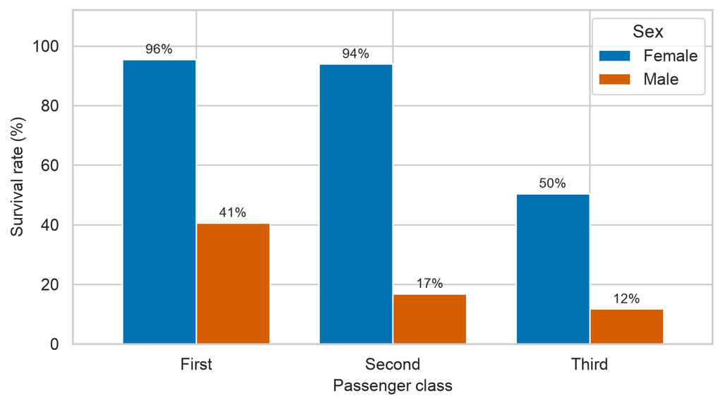

```python
sc = eda.groupby(["Pclass", "Sex"])["Survived"].mean().unstack() * 100
sc.index = ["First", "Second", "Third"]
fig, ax = plt.subplots(figsize=(7, 4))
sc[["female", "male"]].plot.bar(ax=ax, color=[SURV, DIED], rot=0, width=0.75)
ax.set_ylim(0, 112)
ax.set_xlabel("Passenger class")
ax.set_ylabel("Survival rate (%)")
ax.legend(["Female", "Male"], title="Sex", loc="upper right")
for c in ax.containers:
    ax.bar_label(c, fmt="%.0f%%", padding=2, fontsize=9)
fig.tight_layout()
plt.show()
```

*Figure 4. Survival rate by sex, by passenger class and by both together. Use the tabs to switch between the three views.*

**Include in the model?** Yes, both sex and passenger class.

### 3.5.2 Age

```python
known_age = eda.dropna(subset=["Age"]).copy()
known_age["AgeGroup"] = pd.cut(
    known_age["Age"], [0, 12, 18, 35, 60, 100],
    labels=["0-12", "13-18", "19-35", "36-60", "61+"],
)
```

**Age distribution**

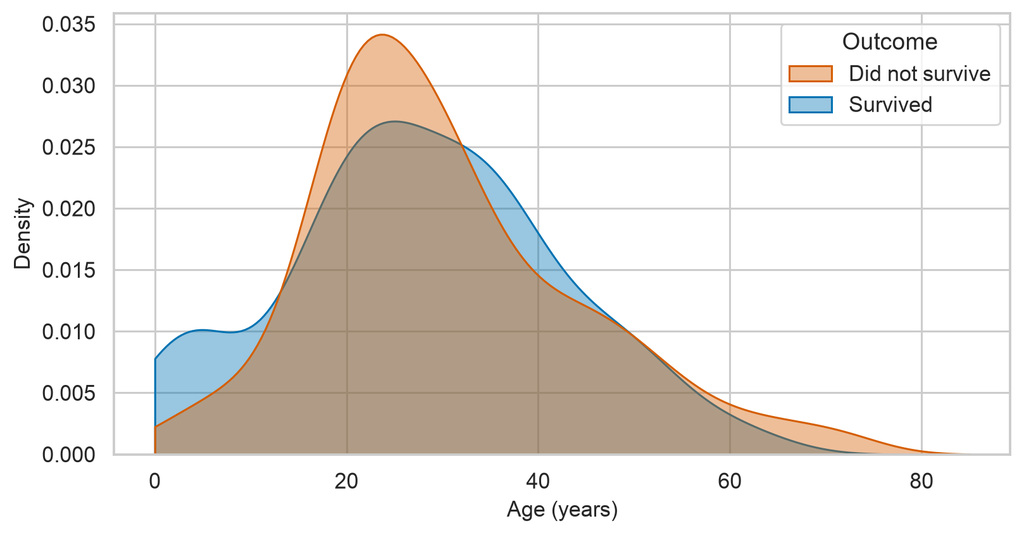

```python
fig, ax = plt.subplots(figsize=(7.5, 4))
sns.kdeplot(data=known_age, x="Age", hue="Outcome", palette=PALETTE, fill=True,
            common_norm=False, alpha=0.4, ax=ax, clip=(0, 85))
ax.set_xlabel("Age (years)")
ax.set_ylabel("Density")
fig.tight_layout()
plt.show()
```

**Survival by age group**

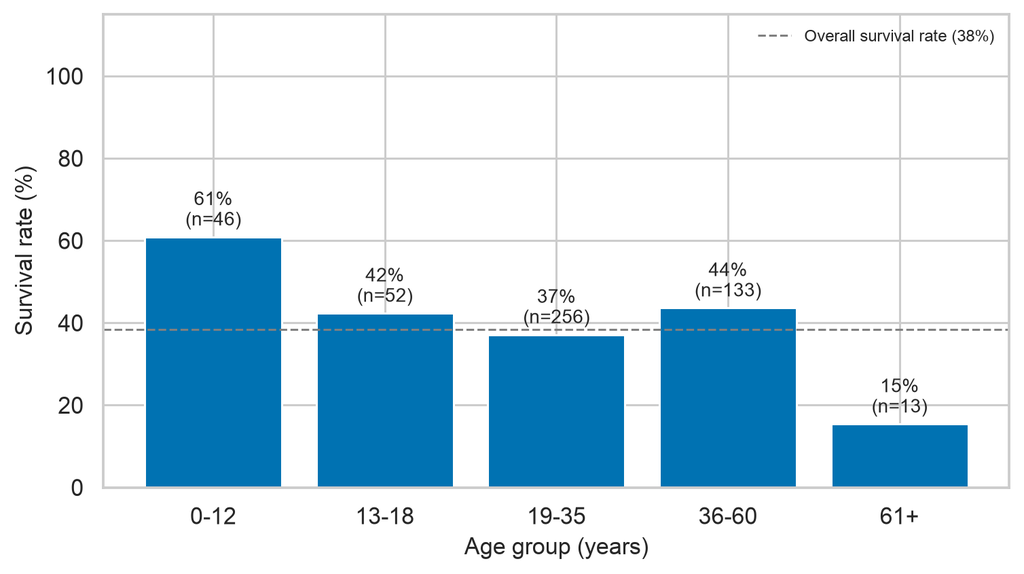

```python
fig, ax = plt.subplots(figsize=(7, 4))
rate_bar(ax, known_age, "AgeGroup", xlabel="Age group (years)")
fig.tight_layout()
plt.show()
```

*Figure 5. Age distribution of survivors and non-survivors, and survival rate by age group. Use the tabs to switch views. Only passengers with a recorded age are shown.*

The age distributions of survivors and non-survivors overlap heavily, but survivors have a clear extra bump of very young children (Figure 5, Age distribution tab). By group, 61% of children aged 12 or under survived, compared with 37% of passengers aged 19 to 35 and only 15% of those aged 61 or over (Figure 5, Survival by age group tab). Survival rates between ages 19 and 60 ranged from 37% to 44%, so the age effect is most pronounced in the youngest and oldest groups, which are small (46 and 13 passengers). A pattern like this shows up only weakly in a single correlation number.

**Include in the model?** Age is a weak feature overall, so it will not be among our top-correlated features, but the child effect in Figure 5 is real. We keep age in the processed data as an optional feature to test in flexible models. It needs imputation for the 19.7% of passengers with no age.

### 3.5.3 Fare

```python
eda["FareLog"] = np.log1p(eda["Fare"])
eda["Class"] = eda["Pclass"].map({1: "First", 2: "Second", 3: "Third"})
```

**Fare distribution**

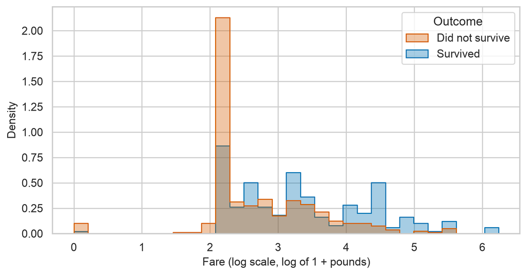

```python
fig, ax = plt.subplots(figsize=(7.5, 4))
sns.histplot(data=eda, x="FareLog", hue="Outcome", palette=PALETTE, bins=30,
             element="step", stat="density", common_norm=False, alpha=0.35, ax=ax)
ax.set_xlabel("Fare (log scale, log of 1 + pounds)")
ax.set_ylabel("Density")
fig.tight_layout()
plt.show()
```

**Fare within each class**

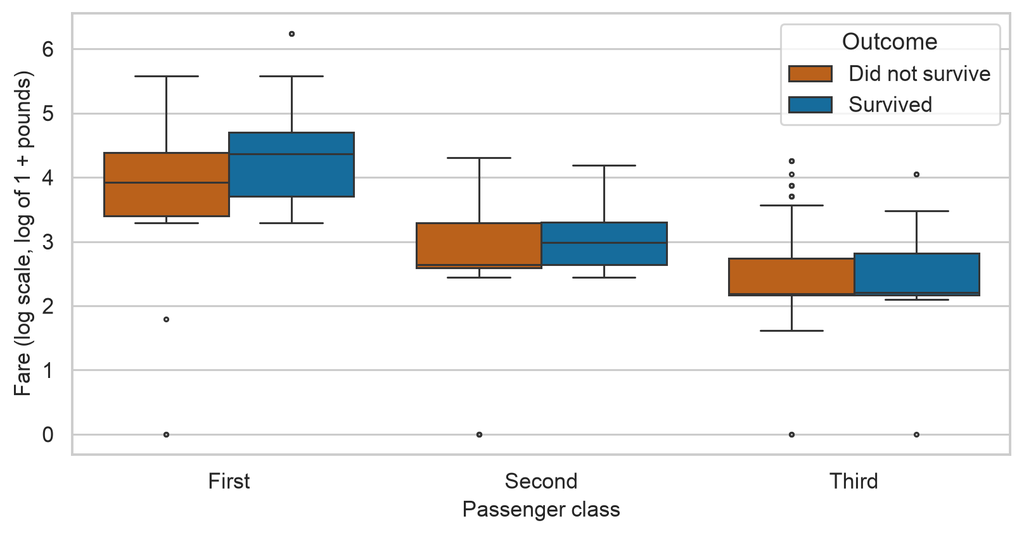

```python
fig, ax = plt.subplots(figsize=(7.5, 4))
sns.boxplot(data=eda, x="Class", y="FareLog", hue="Outcome", palette=PALETTE,
            order=["First", "Second", "Third"], hue_order=["Did not survive", "Survived"],
            fliersize=2, ax=ax)
ax.set_xlabel("Passenger class")
ax.set_ylabel("Fare (log scale, log of 1 + pounds)")
fig.tight_layout()
plt.show()
```

*Figure 6. Distribution of the log fare for survivors and non-survivors, and the log fare within each passenger class. Use the tabs to switch views.*

Fares are extremely right-skewed (skewness of about 5.0), with a maximum of 512.33 pounds and 9 passengers who paid nothing, so we work with the logarithm of one plus the fare instead of the raw value. Survivors paid more: the median fare was 26.0 pounds for survivors and 9.2 pounds for non-survivors. Part of that is simply passenger class, because fare and class are strongly linked, but within first class survivors generally paid more, while fare distributions overlap considerably within second and third class (Figure 6, Fare within each class tab).

**Include in the model?** We retain fare in its log form as a candidate feature. It overlaps with passenger class, which we take into account in the feature selection below. However, fare was not among the five predictors selected from the development set.

### 3.5.4 Family on board

```python
eda["FamilyGroup"] = np.where(eda["FamilySize"] >= 5, "5+", eda["FamilySize"].astype(str))
```

**Family size**

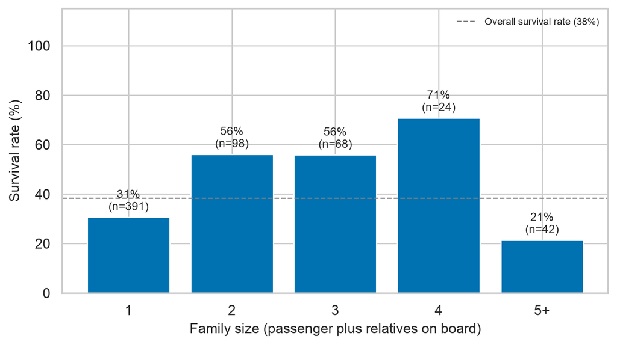

```python
fig, ax = plt.subplots(figsize=(7, 4))
rate_bar(ax, eda, "FamilyGroup", order=["1", "2", "3", "4", "5+"],
         xlabel="Family size (passenger plus relatives on board)")
fig.tight_layout()
plt.show()
```

**Travelling alone**

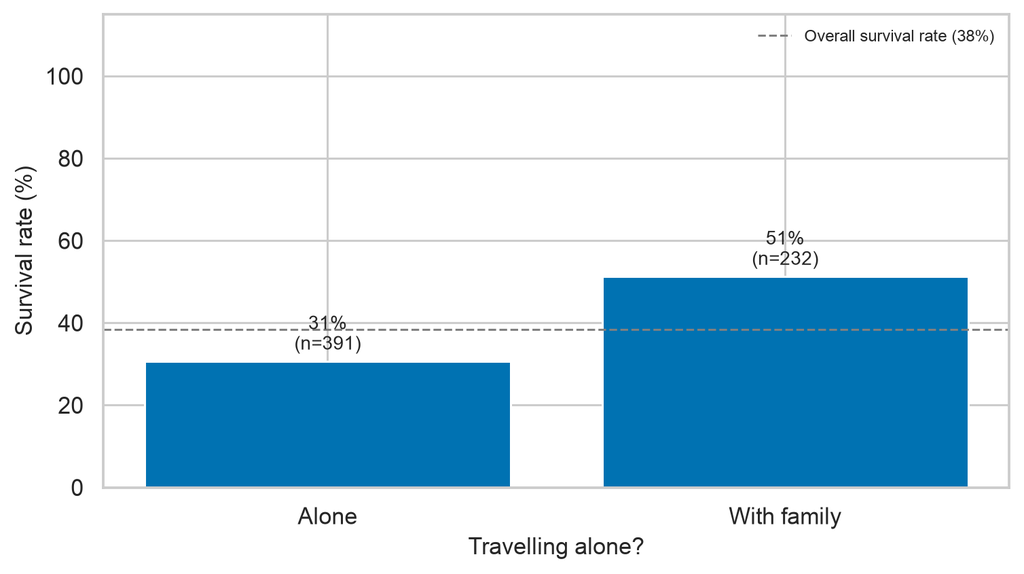

```python
fig, ax = plt.subplots(figsize=(7, 4))
rate_bar(ax, eda, "IsAlone", order=[1, 0], xlabel="Travelling alone?", labels=["Alone", "With family"])
fig.tight_layout()
plt.show()
```

*Figure 7. Survival rate by family size and by whether the passenger travelled alone. Use the tabs to switch views.*

We combined the number of siblings or spouses and the number of parents or children into a single family size (the passenger plus these relatives). Survival is not a straight-line function of family size. People travelling alone survived approximately 31% of the time, small families of two to four did best (56%, 56%, and 71%), and large families of five or more did worst, with only 21% surviving (Figure 7, Family size tab). Collapsing this into “alone versus with family” keeps the main contrast, 31% versus 51% (Figure 7, Travelling alone tab), in a single clean feature.

**Include in the model?** We retain the travelling-alone indicator and the number of parents and children aboard, which were selected among the five predictors from the development set. The number of siblings and spouses was not selected, while family size remains an optional predictor.

### 3.5.5 Port of boarding

```python
port_names = {"C": "Cherbourg", "Q": "Queenstown", "S": "Southampton"}
```

**Survival by port**

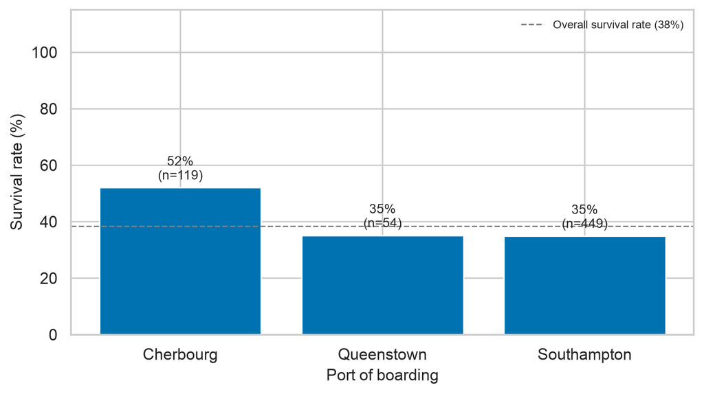

```python
fig, ax = plt.subplots(figsize=(7, 4))
rate_bar(ax, eda, "Embarked", order=["C", "Q", "S"], xlabel="Port of boarding",
         labels=list(port_names.values()))
fig.tight_layout()
plt.show()
```

**Class mix by port**

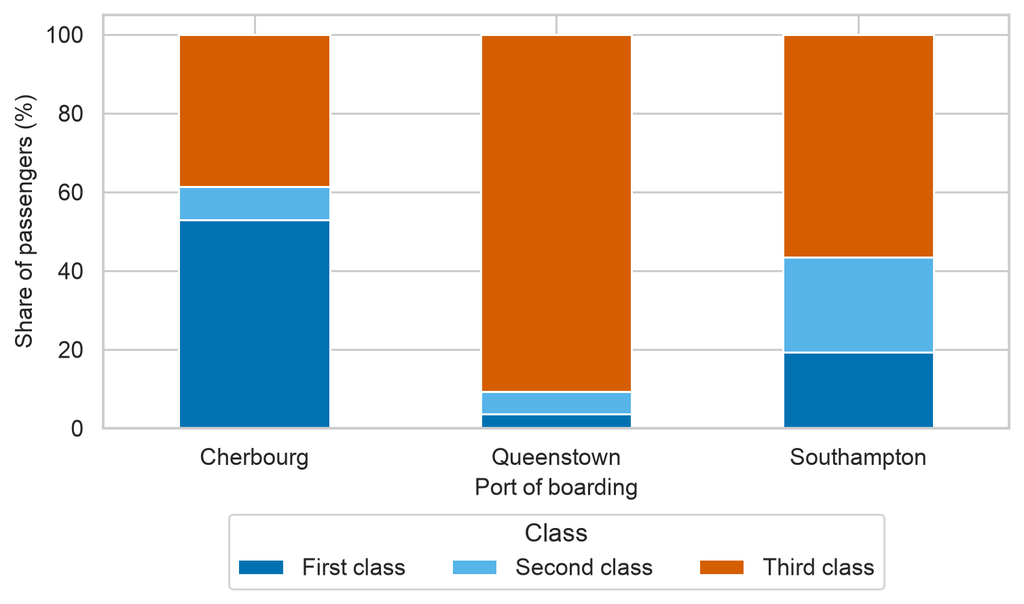

```python
mix = pd.crosstab(eda["Embarked"], eda["Pclass"], normalize="index").loc[["C", "Q", "S"]] * 100
mix.index = list(port_names.values())
mix.columns = ["First class", "Second class", "Third class"]
fig, ax = plt.subplots(figsize=(7, 4.3))
mix.plot.bar(stacked=True, ax=ax, rot=0, color=["#0072B2", "#56B4E9", "#D55E00"])
ax.set_xlabel("Port of boarding")
ax.set_ylabel("Share of passengers (%)")
ax.legend(title="Class", loc="upper center", bbox_to_anchor=(0.5, -0.18), ncol=3)
fig.tight_layout()
plt.show()
```

*Figure 8. Survival rate by port of boarding and the mix of passenger classes among passengers boarding at each port. Use the tabs to switch views. One passenger with no recorded port is left out.*

Passengers who boarded at Cherbourg survived more often (approximately 52%) than those from Queenstown (35%) or Southampton (35%). The “Class mix by port” tab offers a likely reason: a substantially higher proportion of Cherbourg passengers travelled first class than those boarding at Southampton. The port effect may therefore partly reflect differences in passenger class.

**Include in the model?** Although boarding at Cherbourg partly overlaps with passenger class, it was selected among the five predictors from the development set.

### 3.5.6 Title and cabin

**Title**

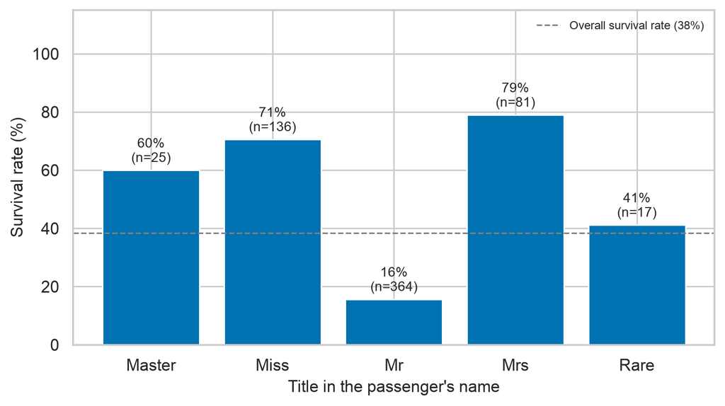

```python
fig, ax = plt.subplots(figsize=(7, 4))
rate_bar(ax, eda, "Title", order=["Master", "Miss", "Mr", "Mrs", "Rare"], xlabel="Title in the passenger's name")
fig.tight_layout()
plt.show()
```

**Cabin recorded, by class**

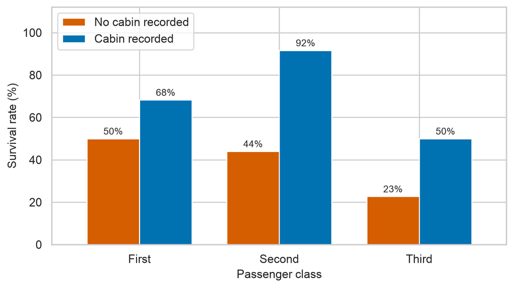

```python
cab = eda.groupby(["Pclass", "HasCabin"])["Survived"].mean().unstack() * 100
cab.index = ["First", "Second", "Third"]
cab.columns = ["No cabin recorded", "Cabin recorded"]
fig, ax = plt.subplots(figsize=(7, 4))
cab.plot.bar(ax=ax, color=[DIED, SURV], rot=0, width=0.75)
ax.set_ylim(0, 112)
ax.set_xlabel("Passenger class")
ax.set_ylabel("Survival rate (%)")
ax.legend(loc="upper left")
for c in ax.containers:
    ax.bar_label(c, fmt="%.0f%%", padding=2, fontsize=9)
fig.tight_layout()
plt.show()
```

*Figure 9. Survival rate by title, and by passenger class and whether a cabin was recorded. Use the tabs to switch views.*

Titles pack sex, age and marital status into one feature: “Master” (young boys) survived 60% of the time, while men titled “Mr” survived only 16%, and “Miss” and “Mrs” survived 71% and 79%. This is mostly the sex effect again, with the useful extra detail that boys fared far better than men.

Having a cabin recorded is associated with higher survival rates in every passenger class (Figure 9, Cabin tab). However, these subgroup comparisons should be interpreted cautiously because some groups may contain relatively few passengers. A possible explanation is that cabin numbers were more likely to be recorded for people who survived to be interviewed, but these data cannot test that. Because most cabin information is missing and a recorded cabin is closely tied to first class, we treat it with care.

**Include in the model?** Title overlaps almost completely with sex, so we keep it in the processed data for later experiments but do not select it. The cabin-recorded flag is kept only if it adds something beyond passenger class, which we test in the correlation analysis.

### 3.5.7 Columns we exclude

The passenger identifier is only a row number and cannot help predict survival. The name is used only to extract the title. The ticket number is a mix of codes with many unique values; a possible future feature is the number of passengers sharing a ticket, but we leave that out for now to keep the analysis simple.

## 3.6 Transforming the data for modelling

We now turn the cleaned columns into a form a model can use. The steps are: fill in missing values using statistics learned from the training data, create the extra features described above, take the logarithm of the fare, and convert categories to 0/1 columns. For the final model and held-out evaluation, the imputation values are learned from the full development training set. During cross-validation, these values are learned separately within each training fold and then applied to its validation fold. We deliberately do not scale the numeric columns here. Scaling is performed inside the modelling pipeline, so its means and standard deviations are also learned separately within each training fold.

```python
def learn_fill_values(df):
    """Learn missing-value replacements using only the supplied training data."""
    train_feat = add_simple_features(df)

    return {
        "age_by_title": train_feat.groupby("Title")["Age"].median(),
        "age_overall": train_feat["Age"].median(),
        "embarked_mode": train_feat["Embarked"].mode()[0],
        "fare_by_class": train_feat.groupby("Pclass")["Fare"].median(),
        "fare_overall": train_feat["Fare"].median(),
    }


# Learn values from the full development set for the final model and held-out evaluation.
fill_values = learn_fill_values(train)

display(fill_values["age_by_title"].rename("Median age (years)").to_frame())
display(fill_values["fare_by_class"].rename("Median fare (pounds)").to_frame())
print("Most common port in the training set:", fill_values["embarked_mode"])
```

| Title | Median age (years) |
| --- | --- |
| Master | 4.0 |
| Miss | 21.0 |
| Mr | 29.0 |
| Mrs | 35.0 |
| Rare | 48.5 |

| Pclass | Median fare (pounds) |
| --- | --- |
| 1 | 63.3583 |
| 2 | 14.0000 |
| 3 | 7.9250 |

```
Most common port in the training set: S
```

*Table 4. Values learned from the training set to fill in missing ages (by title, top), missing fares (by passenger class, middle) and missing ports of boarding (bottom).*

```python
TITLES = ["Master", "Miss", "Mr", "Mrs", "Rare"]

def preprocess(df, fv):
    """Impute, engineer and encode features using fill values learned from the training set."""
    out = add_simple_features(df)
    out["Age"] = out["Age"].fillna(out["Title"].map(fv["age_by_title"])).fillna(fv["age_overall"])
    out["Embarked"] = out["Embarked"].fillna(fv["embarked_mode"])
    out["Fare"] = out["Fare"].fillna(out["Pclass"].map(fv["fare_by_class"])).fillna(fv["fare_overall"])
    out["FareLog"] = np.log1p(out["Fare"])
    out["Sex_female"] = (out["Sex"] == "female").astype(int)
    for port in ["C", "Q", "S"]:
        out[f"Embarked_{port}"] = (out["Embarked"] == port).astype(int)
    for t in TITLES:
        out[f"Title_{t}"] = (out["Title"] == t).astype(int)
    return out

FEATURES = [
    "Pclass", "Sex_female", "Age", "SibSp", "Parch", "Fare", "FareLog", "FamilySize",
    "IsAlone", "HasCabin", "AgeMissing", "Embarked_C", "Embarked_Q", "Embarked_S",
] + [f"Title_{t}" for t in TITLES]

train_p = preprocess(train, fill_values)
holdout_p = preprocess(holdout, fill_values)
test_p = preprocess(test, fill_values)

# Every modelling column must now be complete in all three datasets.
for name, d in [("training", train_p), ("held-out", holdout_p), ("test", test_p)]:
    assert d[FEATURES].isna().sum().sum() == 0, f"missing values left in {name} data"
print("No missing values remain in any modelling column.")
train_p[FEATURES].dtypes.value_counts().rename("Number of columns").to_frame()
```

```
No missing values remain in any modelling column.
```

|  | Number of columns |
| --- | --- |
| int64 | 16 |
| float64 | 3 |

*Table 5. Data types of the modelling columns after the transformations. All 19 columns are numeric.*

All 19 candidate modelling columns are now numeric and complete in the training, held-out test, and original Kaggle test datasets.

## 3.7 Which features relate most strongly to survival?

We now measure the relationship between every feature and survival, and between the features themselves. We use the Pearson correlation coefficient, which for 0/1 columns is also known as the point-biserial or phi coefficient. It runs from -1 to 1: a positive value means the feature goes up when survival is more likely, and a negative value means the opposite. We compute it on the imputed training set, so the correlation for age includes the filled-in ages.

The correlation matrix and feature rankings below describe relationships in the full development training set and help explain our feature-selection approach. For cross-validation, we repeat the same correlation-based selection procedure independently within each training fold, without using its validation fold. The full development set is used to select features again when fitting the final model for held-out evaluation.

### 3.7.1 Correlation matrix

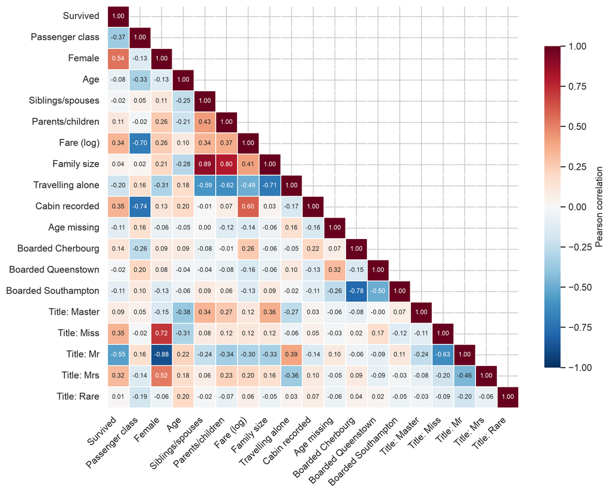

```python
LABELS = {
    "Survived": "Survived", "Pclass": "Passenger class", "Sex_female": "Female", "Age": "Age",
    "SibSp": "Siblings/spouses", "Parch": "Parents/children", "FareLog": "Fare (log)",
    "FamilySize": "Family size", "IsAlone": "Travelling alone", "HasCabin": "Cabin recorded",
    "AgeMissing": "Age missing", "Embarked_C": "Boarded Cherbourg", "Embarked_Q": "Boarded Queenstown",
    "Embarked_S": "Boarded Southampton", "Title_Master": "Title: Master", "Title_Miss": "Title: Miss",
    "Title_Mr": "Title: Mr", "Title_Mrs": "Title: Mrs", "Title_Rare": "Title: Rare",
}
heat_cols = list(LABELS)
corr = train_p[["Survived"] + FEATURES].corr()
heat = corr.loc[heat_cols, heat_cols]
mask = np.triu(np.ones_like(heat, dtype=bool), k=1)

fig, ax = plt.subplots(figsize=(10.5, 8.3))
sns.heatmap(heat, mask=mask, annot=True, fmt=".2f", annot_kws={"size": 7.5},
            cmap="RdBu_r", center=0, vmin=-1, vmax=1, linewidths=0.4, linecolor="white",
            xticklabels=[LABELS[c] for c in heat_cols], yticklabels=[LABELS[c] for c in heat_cols],
            cbar_kws={"label": "Pearson correlation", "shrink": 0.8}, ax=ax)
plt.xticks(rotation=45, ha="right")
plt.yticks(rotation=0)
fig.tight_layout()
plt.show()
```

*Figure 10. Correlation matrix of survival and the candidate features in the training set. Red means a positive correlation and blue a negative one. Fare is shown on the log scale.*

The first column of the heatmap shows how each feature relates to survival, and the rest shows how the features relate to each other. Three things stand out.

First, the strongest links with survival are being female (0.54), having the title “Mr” (-0.55), travelling in a lower class, meaning a higher class number (-0.37), and the log fare (0.34). Second, several features are close to duplicates of each other. Being female and having the title “Mr” are almost mirror images (-0.88), boarding at Cherbourg and Southampton are nearly opposite (-0.78), a recorded cabin follows passenger class (-0.74), and family size follows the alone flag (-0.71). Third, passenger class and the log fare are also related (-0.70), so they partly carry the same information.

### 3.7.2 Ranking the features

Correlation only picks up straight-line relationships, so we also compute the mutual information between each feature and survival, which can detect any kind of dependence. It acts as a second opinion, particularly for age, where the effect is not linear.

```python
corr_target = corr["Survived"].drop("Survived")

# Pick the top features by absolute correlation, skipping any that are nearly duplicates
# (|r| >= 0.70) of one we already picked. We rank one representative per idea:
# the title columns (which mostly repeat sex) and raw fare (replaced by log fare) are left out.
CANDIDATES = ["Sex_female", "Pclass", "HasCabin", "FareLog", "IsAlone", "Embarked_C",
              "Age", "Parch", "FamilySize", "SibSp", "AgeMissing"]
K, REDUNDANT_AT = 5, 0.70
selected, rows = [], []
for f in corr_target[CANDIDATES].abs().sort_values(ascending=False).index:
    clash = [(s, corr.loc[f, s]) for s in selected if abs(corr.loc[f, s]) >= REDUNDANT_AT]
    if len(selected) >= K:
        decision, reason = "Not selected", "top five already chosen"
    elif clash:
        decision, reason = "Not selected", f"near-duplicate of {LABELS[clash[0][0]].lower()} (r = {clash[0][1]:.2f})"
    else:
        selected.append(f)
        decision, reason = "Selected", "high correlation, not redundant"
    rows.append([LABELS[f], round(corr_target[f], 3), decision, reason])
selection = pd.DataFrame(rows, columns=["Feature", "Correlation with survival", "Decision", "Reason"])

mi = pd.Series(
    mutual_info_classif(train_p[FEATURES], train_p["Survived"], random_state=SEED,
                        discrete_features=[f not in ("Age", "Fare", "FareLog") for f in FEATURES]),
    index=FEATURES,
).sort_values(ascending=False)
order = corr_target.abs().sort_values().index
mi_order = mi.sort_values()
```

**Correlation with survival**

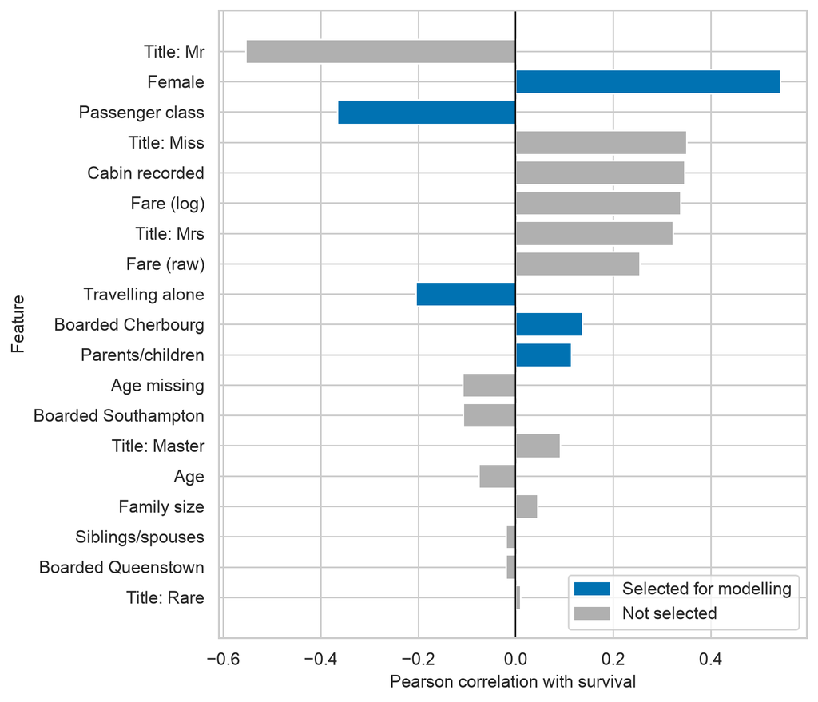

```python
fig, ax = plt.subplots(figsize=(7.5, 6.5))
colors = [SURV if f in selected else "#B0B0B0" for f in order]
ax.barh([LABELS.get(f, "Fare (raw)") for f in order], corr_target[order], color=colors)
ax.axvline(0, color="black", lw=0.8)
ax.set_xlabel("Pearson correlation with survival")
ax.set_ylabel("Feature")
ax.legend(handles=[Patch(color=SURV, label="Selected for modelling"),
                   Patch(color="#B0B0B0", label="Not selected")], loc="lower right")
fig.tight_layout()
plt.show()
```

**Mutual information**

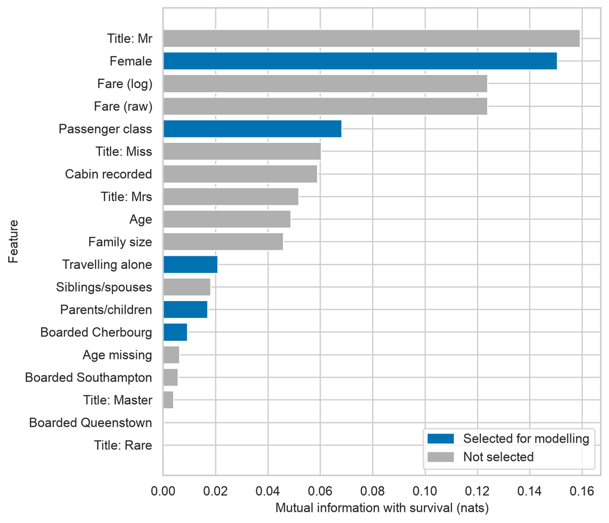

```python
fig, ax = plt.subplots(figsize=(7.5, 6.5))
ax.barh([LABELS.get(f, "Fare (raw)") for f in mi_order.index], mi_order.values,
        color=[SURV if f in selected else "#B0B0B0" for f in mi_order.index])
ax.set_xlabel("Mutual information with survival (nats)")
ax.set_ylabel("Feature")
ax.legend(handles=[Patch(color=SURV, label="Selected for modelling"),
                   Patch(color="#B0B0B0", label="Not selected")], loc="lower right")
fig.tight_layout()
plt.show()
```

*Figure 11. Features ranked by their correlation with survival (sorted by absolute size, with the sign shown by the direction of the bar) and by mutual information with survival. Use the tabs to switch views. Selected features are highlighted.*

```python
selection
```

|  | Feature | Correlation with survival | Decision | Reason |
| --- | --- | --- | --- | --- |
| 0 | Female | 0.543 | Selected | high correlation, not redundant |
| 1 | Passenger class | -0.366 | Selected | high correlation, not redundant |
| 2 | Cabin recorded | 0.346 | Not selected | near-duplicate of passenger class (r = -0.74) |
| 3 | Fare (log) | 0.338 | Not selected | near-duplicate of passenger class (r = -0.70) |
| 4 | Travelling alone | -0.205 | Selected | high correlation, not redundant |
| 5 | Boarded Cherbourg | 0.137 | Selected | high correlation, not redundant |
| 6 | Parents/children | 0.115 | Selected | high correlation, not redundant |
| 7 | Age missing | -0.109 | Not selected | top five already chosen |
| 8 | Age | -0.076 | Not selected | top five already chosen |
| 9 | Family size | 0.045 | Not selected | top five already chosen |
| 10 | Siblings/spouses | -0.020 | Not selected | top five already chosen |

*Table 6. Selection of the five features most strongly correlated with survival, skipping near-duplicates of features already chosen.*

The five features we select are sex, passenger class, travelling alone, boarding at Cherbourg, and the number of parents and children aboard. They come from walking down the correlation ranking and skipping any feature that nearly repeats one already chosen. The “cabin recorded” flag is correlated with survival (0.35) but is skipped because it is strongly associated with passenger class (-0.74), and most cabin values are missing. The title columns are left out of the ranking because they mostly restate sex (-0.88 with the title “Mr”), even though their raw correlations are as high as the top feature. The raw fare is replaced by the log fare, which remains a candidate but was not among the five selected features.

Two caveats matter. The log fare is strongly correlated with passenger class (-0.70), close to our 0.70 cut-off for redundancy, so these two features overlap noticeably. Log fare was not selected among the five development-set predictors. Boarding at Cherbourg has a relatively weak correlation with survival (0.14) and partly reflects passenger class, as seen in Figure 8. The number of parents and children aboard was selected despite its modest correlation with survival (0.11).

The mutual information ranking agrees that sex, title and fare are the most informative. It scores travelling alone (approximately 0.02), parents/children (approximately 0.02) and boarding at Cherbourg (approximately 0.01) much lower, although these features were selected by the correlation-based method. Age scores around 0.05 despite its weak linear correlation with survival (-0.08), consistent with the age-group pattern in Figure 5. Family size is a similar case: its correlation with survival is close to zero (0.04), yet its mutual information (approximately 0.05) is higher than that of travelling alone, which fits the non-linear pattern in Figure 7. We keep age and family size in the processed data as optional features, although they are not among the five selected by correlation.

## 3.8 Summary of the exploratory analysis

| Feature | Decision | Main reason |
| --- | --- | --- |
| Sex | Include | Strongest single signal (see Figure 4). |
| Passenger class | Include | Survival falls steadily from first to third class and interacts with sex. |
| Fare (log) | Not selected | Survivors paid more, and the log scale reduces extreme skew. However, fare was not among the five features selected from the development set. |
| Travelling alone | Include | People travelling alone survived much less often than those with family. |
| Port: Cherbourg | Include (weak) | Higher survival, but mostly a first-class effect. |
| Age | Optional | Weak by both measures, but children survived more; needs imputation. |
| Title | Optional | Mostly repeats sex; adds boys versus men. |
| Cabin recorded | Drop | Nearly the same as passenger class; mostly missing. |
| Siblings/spouses | Drop | Not among the five selected predictors; travelling alone retains some information about family travel. |
| Parents/children | Include | Selected among the five predictors using the development dataset. |
| Family size | Optional | No linear link, but a non-linear pattern; the alone flag is the simpler version. |
| Passenger ID, name, ticket | Drop | Identifiers, or only useful through the title. |

*Table 7. Summary of our decision for each feature.*

In short, a passenger’s chance of survival depended most on being a woman, travelling in a higher class and having paid a higher fare, with smaller contributions from travelling with family and from the port of boarding. About a fifth of the ages and most of the cabins were missing, and the missing values were themselves linked to survival. These findings describe associations in this one historical dataset; they do not show that any single factor caused a passenger to survive.

Two limitations apply to the conclusions above. First, correlation and mutual information look at one feature at a time, so they can miss combinations such as the sex-by-class interaction in Figure 4, and a feature that is weak on its own may still help a model. Second, our development set contains only 623 passengers, so small groups (for example older passengers or the rare titles) give noisy rates, and our selected features should be treated as a starting point that the model comparison can confirm or revise.

## 3.9 Saving the processed data

We save the processed training and test data to the processed data folder, both using the fill values learned from the training data. The files keep all 19 candidate features, so the modelling stage can choose among them, together with the passenger identifier and, for the training file, the survival outcome. Our five selected features are stored in a short text file so that teammates can load the same list. The held-out test set of 268 passengers is processed using the same imputation values learned from the development set and is kept separate for final model evaluation.

```python
KEEP = ["PassengerId"] + FEATURES
train_p[KEEP + ["Survived"]].to_csv(PROC_DIR / "train_processed.csv", index=False)
test_p[KEEP].to_csv(PROC_DIR / "test_processed.csv", index=False)
(PROC_DIR / "selected_features.txt").write_text("\n".join(selected) + "\n")

print("Selected features:", selected)
print(f"train_processed.csv: {len(train_p)} rows x {len(KEEP) + 1} columns")
print(f"test_processed.csv: {len(test_p)} rows x {len(KEEP)} columns")
```

```
Selected features: ['Sex_female', 'Pclass', 'IsAlone', 'Embarked_C', 'Parch']
train_processed.csv: 623 rows x 21 columns
test_processed.csv: 418 rows x 20 columns
```

# 4 Predictive modelling with logistic regression

In this section, we build a classification pipeline using logistic regression (Pedregosa et al. 2011) combined with feature standardization. During five-fold stratified cross-validation, imputation values and selected features are learned separately within each training fold. The validation fold is processed using the corresponding training-fold values and selected features. Standardization is also fitted within the modelling pipeline, ensuring that information from each validation fold does not influence model fitting.

To connect our exploratory findings with the modelling stage without repeating the individual feature analyses, we test whether adding the optional features kept in the processed data (age, family size, and the passenger title indicators for “Master”, “Miss”, and “Mrs”) together with the interaction between sex and passenger class identified in Figure 4 improves cross-validation performance over the five predictors selected independently within each cross-validation training fold.

```python
from sklearn.dummy import DummyClassifier
from sklearn.linear_model import LogisticRegression
from sklearn.preprocessing import StandardScaler
from sklearn.pipeline import Pipeline
from sklearn.model_selection import StratifiedKFold, cross_validate
from sklearn.metrics import roc_auc_score, confusion_matrix, roc_curve, accuracy_score, precision_score, recall_score, f1_score

train_mod = pd.read_csv(PROC_DIR / "train_processed.csv")
holdout_mod = holdout_p.copy()
test_mod = pd.read_csv(PROC_DIR / "test_processed.csv")
selected_5 = (PROC_DIR / "selected_features.txt").read_text().strip().splitlines()

# Create the sex-by-class interaction for the final datasets.
for df_m in (train_mod, holdout_mod, test_mod):
    df_m["Sex_x_Pclass"] = df_m["Sex_female"] * df_m["Pclass"]

extended_cols = selected_5 + [
    "Age", "FamilySize", "Sex_x_Pclass", "Title_Master", "Title_Miss", "Title_Mrs"
]

y_train = train["Survived"]
cv = StratifiedKFold(n_splits=5, shuffle=True, random_state=SEED)
scoring = ["accuracy", "precision", "recall", "f1", "roc_auc"]


def prepare_fold_data(train_idx, val_idx):
    """Preprocess each fold using imputation values learned from its training part only."""
    fold_train_raw = train.iloc[train_idx].copy()
    fold_val_raw = train.iloc[val_idx].copy()

    # Learn imputation values from this training fold only.
    fold_fill_values = learn_fill_values(fold_train_raw)

    # Apply the same fold-specific values to training and validation data.
    fold_train = preprocess(fold_train_raw, fold_fill_values)
    fold_val = preprocess(fold_val_raw, fold_fill_values)

    # Create the interaction feature.
    for df_fold in (fold_train, fold_val):
        df_fold["Sex_x_Pclass"] = df_fold["Sex_female"] * df_fold["Pclass"]

    return fold_train, fold_val


def select_fold_features(fold_train):
    """Select five features using correlations calculated on the training fold only."""
    fold_corr = fold_train[["Survived"] + CANDIDATES].corr()

    ranked = (
        fold_corr["Survived"]
        .drop("Survived")
        .abs()
        .sort_values(ascending=False)
        .index
    )

    chosen = []
    for feature in ranked:
        if len(chosen) == K:
            break

        if all(
            abs(fold_corr.loc[feature, selected]) < REDUNDANT_AT
            for selected in chosen
        ):
            chosen.append(feature)

    return chosen


# The dummy classifier does not use the predictors.
dummy_res = cross_validate(
    DummyClassifier(strategy="most_frequent"),
    np.zeros((len(y_train), 1)),
    y_train,
    cv=cv,
    scoring=["accuracy", "roc_auc"]
)

cv_rows = [{
    "Model": "Baseline (most frequent outcome)",
    "Number of features": 0,
    "CV accuracy (mean ± SD)": f"{dummy_res['test_accuracy'].mean():.3f} ± {dummy_res['test_accuracy'].std():.3f}",
    "Precision": 0.0,
    "Recall": 0.0,
    "F1-score": 0.0,
    "ROC-AUC": dummy_res["test_roc_auc"].mean(),
}]

for label, extras in [
    ("Logistic regression (5 selected features)", []),
    ("Logistic regression (5 selected + optional & sex-by-class interaction)",
     ["Age", "FamilySize", "Sex_x_Pclass", "Title_Master", "Title_Miss", "Title_Mrs"]),
]:
    fold_results = []
    fold_counts = []

    for train_idx, val_idx in cv.split(train, y_train):
        # Preprocessing and feature selection use the training fold only.
        fold_train, fold_val = prepare_fold_data(train_idx, val_idx)
        fold_selected = select_fold_features(fold_train)

        cols = fold_selected + [f for f in extras if f not in fold_selected]
        fold_counts.append(len(cols))

        pipe = Pipeline([
            ("scaler", StandardScaler()),
            ("logreg", LogisticRegression(C=1.0, max_iter=1000, random_state=SEED)),
        ])

        pipe.fit(fold_train[cols], fold_train["Survived"])

        actual = fold_val["Survived"]
        predicted = pipe.predict(fold_val[cols])
        probabilities = pipe.predict_proba(fold_val[cols])[:, 1]

        fold_results.append({
            "accuracy": accuracy_score(actual, predicted),
            "precision": precision_score(actual, predicted, zero_division=0),
            "recall": recall_score(actual, predicted),
            "f1": f1_score(actual, predicted),
            "roc_auc": roc_auc_score(actual, probabilities),
        })

    results = pd.DataFrame(fold_results)

    cv_rows.append({
        "Model": label,
        "Number of features": round(np.mean(fold_counts), 1),
        "CV accuracy (mean ± SD)": f"{results['accuracy'].mean():.3f} ± {results['accuracy'].std(ddof=0):.3f}",
        "Precision": results["precision"].mean(),
        "Recall": results["recall"].mean(),
        "F1-score": results["f1"].mean(),
        "ROC-AUC": results["roc_auc"].mean(),
    })

display(pd.DataFrame(cv_rows).round(3))
```

|  | Model | Number of features | CV accuracy (mean ± SD) | Precision | Recall | F1-score | ROC-AUC |
| --- | --- | --- | --- | --- | --- | --- | --- |
| 0 | Baseline (most frequent outcome) | 0.0 | 0.616 ± 0.003 | 0.000 | 0.000 | 0.000 | 0.500 |
| 1 | Logistic regression (5 selected features) | 5.0 | 0.778 ± 0.020 | 0.713 | 0.712 | 0.711 | 0.829 |
| 2 | Logistic regression (5 selected + optional & s... | 11.0 | 0.823 ± 0.060 | 0.803 | 0.724 | 0.759 | 0.870 |

*Table 8. Five-fold stratified cross-validation performance comparing the majority-class baseline, logistic regression on five features selected by correlation within each training fold, and logistic regression adding the optional features and the interaction between sex and passenger class.*

## 4.1 Diagnostic evaluation and feature weights

We examine out-of-fold predictions and standardized coefficients for the extended logistic regression model using the 623-observation development set. We then evaluate the final model on the independent held-out test set of 268 passengers and generate survival predictions for Kaggle’s original 418 unlabeled test observations.

```python
ext_pipe = Pipeline([
    ("scaler", StandardScaler()),
    ("logreg", LogisticRegression(C=1.0, max_iter=1000, random_state=SEED)),
])

# Generate out-of-fold predictions with preprocessing and feature selection
# performed independently within each training fold.
oof_pred = np.zeros(len(train_mod), dtype=int)
oof_prob = np.zeros(len(train_mod), dtype=float)

for train_idx, val_idx in cv.split(train, y_train):
    fold_train, fold_val = prepare_fold_data(train_idx, val_idx)

    fold_selected = select_fold_features(fold_train)
    optional = [
        "Age", "FamilySize", "Sex_x_Pclass",
        "Title_Master", "Title_Miss", "Title_Mrs"
    ]
    fold_cols = fold_selected + [
        f for f in optional if f not in fold_selected
    ]

    fold_pipe = Pipeline([
        ("scaler", StandardScaler()),
        ("logreg", LogisticRegression(C=1.0, max_iter=1000, random_state=SEED)),
    ])

    fold_pipe.fit(fold_train[fold_cols], fold_train["Survived"])
    oof_pred[val_idx] = fold_pipe.predict(fold_val[fold_cols])
    oof_prob[val_idx] = fold_pipe.predict_proba(fold_val[fold_cols])[:, 1]

cm = confusion_matrix(y_train, oof_pred)

# Fit the final model using the complete development training set.
# Imputation values and selected features are learned from that full set.
ext_pipe.fit(train_mod[extended_cols], y_train)

# Evaluate the final model on the independent held-out test set.
y_holdout = holdout_mod["Survived"]
holdout_pred = ext_pipe.predict(holdout_mod[extended_cols])

print("Held-out accuracy:", round(accuracy_score(y_holdout, holdout_pred), 3))
print("Held-out F1 score:", round(f1_score(y_holdout, holdout_pred), 3))
print("Held-out confusion matrix:")
print(confusion_matrix(y_holdout, holdout_pred))

coefs = pd.Series(
    ext_pipe.named_steps["logreg"].coef_[0],
    index=extended_cols
).sort_values()

test_pred = ext_pipe.predict(test_mod[extended_cols])
test_prob = ext_pipe.predict_proba(test_mod[extended_cols])[:, 1]

pd.DataFrame({
    "PassengerId": test_mod["PassengerId"],
    "Survived": test_pred,
    "PredictedProbability": test_prob.round(4),
}).to_csv(PROC_DIR / "test_predictions.csv", index=False)
```

```
Held-out accuracy: 0.847
Held-out F1 score: 0.79
Held-out confusion matrix:
[[150  15]
 [ 26  77]]
```

**Confusion matrix & ROC**

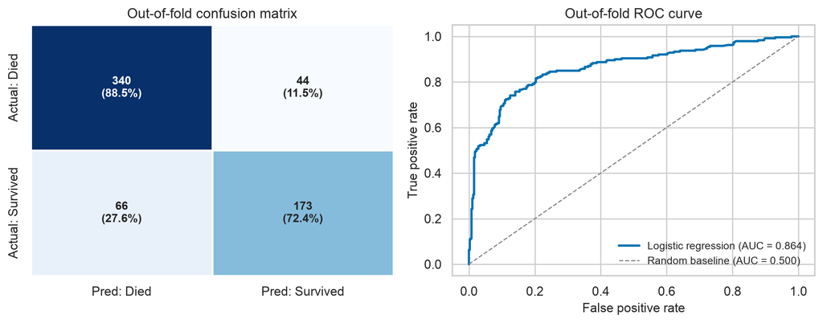

```python
cm_pct = cm / cm.sum(axis=1, keepdims=True) * 100
annot = np.array([
    [f"{cm[i, j]}\n({cm_pct[i, j]:.1f}%)" for j in range(2)]
    for i in range(2)
])
fpr, tpr, _ = roc_curve(y_train, oof_prob)
oof_auc = roc_auc_score(y_train, oof_prob)

fig, (ax1, ax2) = plt.subplots(1, 2, figsize=(10.2, 4.1))
sns.heatmap(
    cm, annot=annot, fmt="", cmap="Blues", cbar=False,
    xticklabels=["Pred: Died", "Pred: Survived"],
    yticklabels=["Actual: Died", "Actual: Survived"],
    annot_kws={"size": 10, "weight": "bold"}, linewidths=1, linecolor="white", ax=ax1
)
ax1.set_title("Out-of-fold confusion matrix")

ax2.plot(fpr, tpr, color=SURV, lw=2, label=f"Logistic regression (AUC = {oof_auc:.3f})")
ax2.plot([0, 1], [0, 1], ls="--", color="#888888", lw=1, label="Random baseline (AUC = 0.500)")
ax2.set_xlabel("False positive rate")
ax2.set_ylabel("True positive rate")
ax2.set_title("Out-of-fold ROC curve")
ax2.legend(loc="lower right", frameon=False, fontsize=9)
fig.tight_layout()
plt.show()
```

**Standardized coefficients**

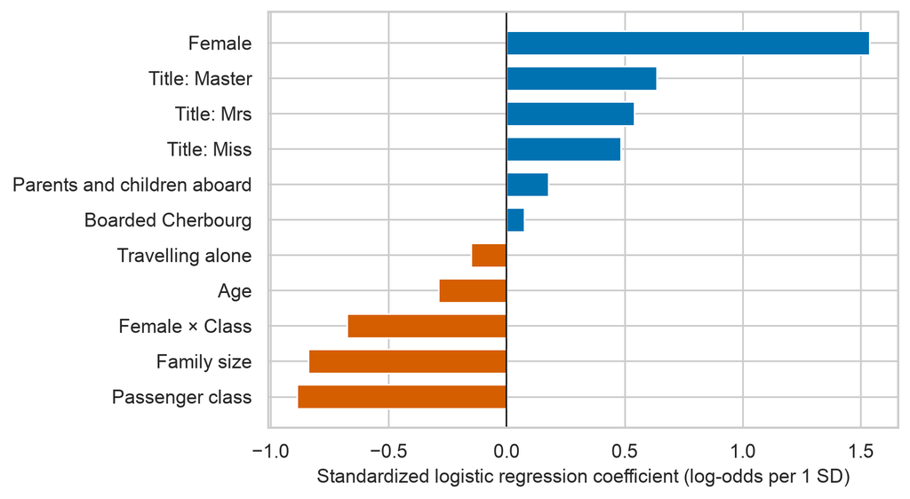

```python
FEATURE_NAMES = {
    "Sex_female": "Female", "Title_Mrs": "Title: Mrs", "Title_Master": "Title: Master",
    "Title_Miss": "Title: Miss", "FareLog": "Fare (log)", "Embarked_C": "Boarded Cherbourg",
    "IsAlone": "Travelling alone", "Sex_x_Pclass": "Female × Class", "Age": "Age",
    "Pclass": "Passenger class", "FamilySize": "Family size",
    "Parch": "Parents and children aboard",
}
fig, ax = plt.subplots(figsize=(7.5, 4.2))
colors = [SURV if v > 0 else DIED for v in coefs.values]
ax.barh([FEATURE_NAMES[c] for c in coefs.index], coefs.values, color=colors, height=0.68)
ax.axvline(0, color="black", lw=0.8)
ax.set_xlabel("Standardized logistic regression coefficient (log-odds per 1 SD)")
fig.tight_layout()
plt.show()
```

*Figure 12. Out-of-fold confusion matrix and ROC curve (first tab) and standardized coefficients (second tab) for the extended logistic regression pipeline. Use the tabs to switch views.*